# Unidad 4 — Algoritmos de Ordenamiento

### Implementación de los algoritmos

Implementé los cuatro algoritmos de forma que, además de ordenar, devuelvan el número de comparaciones realizadas. Eso me permite analizar no solo el tiempo de pared sino también el trabajo interno de cada método, que es lo que realmente dice la teoría de complejidad.

#### Bubblesort adaptativo

```julia
function adaptive_bubble_sort(arr::Vector{Int})
    A = copy(arr)
    n = length(A)
    num_comps = 0

    for i in 1:n-1
        swapped = false
        for j in 1:n-i
            num_comps += 1
            if A[j] > A[j+1]
                A[j], A[j+1] = A[j+1], A[j]
                swapped = true
            end
        end
        swapped || break
    end

    return A, num_comps
end
```

```
adaptive_bubble_sort (generic function with 1 method)
```

Se cuenta cada comparación entre elementos adyacentes. Si en toda una pasada no hubo intercambios, el arreglo ya está ordenado y se puede salir del ciclo anticipadamente: esa es la propiedad adaptativa del algoritmo.

#### Mergesort

Mergesort divide el arreglo a la mitad recursivamente, ordena cada parte y luego las fusiona. El único detalle de implementación que no es obvio es cómo pasar el contador de comparaciones entre llamadas recursivas: en Julia no se puede modificar un entero pasado por argumento, así que usé `Ref{Int}`, que es esencialmente un puntero a un entero mutable.

```julia
function mergesort(arr::Vector{Int})
    A = copy(arr)
    num_comps = Ref(0)
    _msort!(A, 1, length(A), num_comps)
    return A, num_comps[]
end

function _msort!(A::Vector{Int}, lo::Int, hi::Int, num_comps::Ref{Int})
    if lo < hi
        mid = div(lo + hi, 2)
        _msort!(A, lo, mid, num_comps)
        _msort!(A, mid + 1, hi, num_comps)
        _merge!(A, lo, mid, hi, num_comps)
    end
end

function _merge!(A::Vector{Int}, lo::Int, mid::Int, hi::Int, num_comps::Ref{Int})
    left  = A[lo:mid]
    right = A[mid+1:hi]
    i = j = 1
    k = lo

    while i <= length(left) && j <= length(right)
        num_comps[] += 1
        if left[i] <= right[j]
            A[k] = left[i]; i += 1
        else
            A[k] = right[j]; j += 1
        end
        k += 1
    end

    # Copiar los elementos restantes de cada mitad
    while i <= length(left);  A[k] = left[i];  i += 1; k += 1; end
    while j <= length(right); A[k] = right[j]; j += 1; k += 1; end
end
```

```
_merge! (generic function with 1 method)
```

#### Quicksort

La implementación sigue el enfoque del curso: selección aleatoria de pivote para evitar el peor caso cuadrático en arreglos ya ordenados (Cormen et al. 2022).

```julia
function quicksort(arr::Vector{Int})
    A = copy(arr)
    num_comps = Ref(0)
    _qsort!(A, 1, length(A), num_comps)
    return A, num_comps[]
end

function _qsort!(A::Vector{Int}, lo::Int, hi::Int, num_comps::Ref{Int})
    if lo < hi
        pivot_idx = _partition!(A, lo, hi, num_comps)
        _qsort!(A, lo, pivot_idx - 1, num_comps)
        _qsort!(A, pivot_idx + 1, hi, num_comps)
    end
end

function _partition!(A::Vector{Int}, lo::Int, hi::Int, num_comps::Ref{Int})
    # Pivote aleatorio para reducir la probabilidad del peor caso
    ipiv = rand(lo:hi)
    A[ipiv], A[hi] = A[hi], A[ipiv]
    pivot = A[hi]

    i = lo - 1
    for j in lo:hi-1
        num_comps[] += 1
        if A[j] < pivot
            i += 1
            A[i], A[j] = A[j], A[i]
        end
    end

    A[i+1], A[hi] = A[hi], A[i+1]
    return i + 1
end
```

```
_partition! (generic function with 1 method)
```

#### Heapsort

Heapsort tiene dos fases bien separadas: primero reorganiza el arreglo como un max-heap, y luego extrae el máximo repetidamente para construir el resultado ordenado de atrás hacia adelante. Todo ocurre dentro del mismo arreglo, sin memoria auxiliar, lo que lo distingue de Mergesort.

```julia
function heapsort(arr::Vector{Int})
    A = copy(arr)
    n = length(A)
    num_comps = Ref(0)

    # Fase 1: construir el heap en O(n)
    for i in div(n, 2):-1:1
        _sift_down!(A, n, i, num_comps)
    end

    # Fase 2: extraer el máximo repetidamente
    for i in n:-1:2
        A[1], A[i] = A[i], A[1]
        _sift_down!(A, i - 1, 1, num_comps)
    end

    return A, num_comps[]
end

function _sift_down!(A::Vector{Int}, heap_size::Int, root::Int, num_comps::Ref{Int})
    largest = root
    left  = 2 * root
    right = 2 * root + 1

    if left <= heap_size
        num_comps[] += 1
        largest = A[left] > A[largest] ? left : largest
    end
    if right <= heap_size
        num_comps[] += 1
        largest = A[right] > A[largest] ? right : largest
    end

    if largest != root
        A[root], A[largest] = A[largest], A[root]
        _sift_down!(A, heap_size, largest, num_comps)
    end
end
```

```
_sift_down! (generic function with 1 method)
```

### Verificación de correctitud

Antes de correr los experimentos sobre los arreglos reales, comprobé que los cuatro algoritmos producen el resultado correcto con un arreglo pequeño de prueba. Es un paso sencillo pero evita desperdiciar tiempo interpretando resultados de un algoritmo con bug.

```julia
test_arr = [5, 1, 4, 8, 2, 6, 3, 7]
println("Arreglo de prueba: ", test_arr, "\n")

algoritmos = [
    ("Bubble Adaptativo", adaptive_bubble_sort),
    ("Mergesort",         mergesort),
    ("Quicksort",         quicksort),
    ("Heapsort",          heapsort),
]

for (nombre, fn) in algoritmos
    resultado, comps = fn(test_arr)
    estado = issorted(resultado) ? "OK" : "ERROR"
    @printf("[%s]  %-20s → %s  (%d comparaciones)\n",
            estado, nombre, resultado, comps)
end
```

```
Arreglo de prueba: [5, 1, 4, 8, 2, 6, 3, 7]

[OK]  Bubble Adaptativo    → [1, 2, 3, 4, 5, 6, 7, 8]  (25 comparaciones)
[OK]  Mergesort            → [1, 2, 3, 4, 5, 6, 7, 8]  (17 comparaciones)
[OK]  Quicksort            → [1, 2, 3, 4, 5, 6, 7, 8]  (13 comparaciones)
[OK]  Heapsort             → [1, 2, 3, 4, 5, 6, 7, 8]  (27 comparaciones)
```

### Experimentos

Corrí cada algoritmo sobre los seis arreglos y registré tanto las comparaciones como el tiempo. Para el tiempo hice 5 repeticiones y tomé el promedio, porque Julia compila las funciones en el primer llamado (JIT) y esa primera ejecución inflaría el tiempo si solo se midiera una vez.

```julia
n_p   = length(p_values)
n_alg = length(algoritmos)
REPS  = 5

mat_comps  = zeros(Int,     n_p, n_alg)
mat_tiempo = zeros(Float64, n_p, n_alg)

for (i, p) in enumerate(p_values)
    arr = datos[p]
    for (j, (_, fn)) in enumerate(algoritmos)
        sorted_arr, c = fn(arr)
        mat_comps[i, j] = c
        mat_tiempo[i, j] = mean([@elapsed fn(arr) for _ in 1:REPS])
    end
end
```

### Resultados

#### Tabla de comparaciones

```julia
nombres_alg = [a[1] for a in algoritmos]
col_w = 22

println(rpad("p", 6), join(rpad.(nombres_alg, col_w)))
println("-" ^ (6 + col_w * n_alg))
for (i, p) in enumerate(p_values)
    println(rpad(string(p), 6),
            join(rpad.(string.(mat_comps[i, :]), col_w)))
end
```

```
p     Bubble Adaptativo     Mergesort             Quicksort             Heapsort
----------------------------------------------------------------------------------------------
16    3705580               23867                 39240                 64787
32    4462282               24791                 41667                 64715
64    4722157               26917                 43444                 64654
128   4684707               28882                 42342                 64536
256   4740799               29803                 43196                 64315
512   4734400               30845                 39927                 63936
```

#### Tabla de tiempos promedio (segundos)

```julia
println(rpad("p", 6), join(rpad.(nombres_alg, col_w)))
println("-" ^ (6 + col_w * n_alg))
for (i, p) in enumerate(p_values)
    fmts = [@sprintf("%.6f", mat_tiempo[i, j]) for j in 1:n_alg]
    println(rpad(string(p), 6), join(rpad.(fmts, col_w)))
end
```

```
p     Bubble Adaptativo     Mergesort             Quicksort             Heapsort
----------------------------------------------------------------------------------------------
16    0.004646              0.000411              0.000122              0.000260
32    0.005642              0.007865              0.000164              0.000329
64    0.006185              0.000437              0.000146              0.000270
128   0.006185              0.000625              0.000163              0.000336
256   0.008095              0.001172              0.000183              0.000320
512   0.008419              0.000559              0.000171              0.000266
```

#### Razón de comparaciones respecto a $n \log_2 n$

Para los algoritmos $O(n \log n)$, la razón $C / (n \log_2 n)$ debería mantenerse aproximadamente constante. Un valor alto indica mayor constante multiplicativa; Bubblesort excede este valor notoriamente para $p$ grande.

```julia
n_arr   = length(datos[16])
nlogn   = n_arr * log2(n_arr)

println(rpad("p", 6), join(rpad.(nombres_alg, col_w)))
println(rpad("",  6), join(rpad.(fill("(C / n·log₂n)", col_w), n_alg)))
println("-" ^ (6 + col_w * n_alg))
for (i, p) in enumerate(p_values)
    fmts = [@sprintf("%.4f", mat_comps[i, j] / nlogn) for j in 1:n_alg]
    println(rpad(string(p), 6), join(rpad.(fmts, col_w)))
end
```

```
p     Bubble Adaptativo     Mergesort             Quicksort             Heapsort
      (C / n·log₂n)(C / n·log₂n)(C / n·log₂n)(C / n·log₂n)(C / n·log₂n)(C / n·log₂n)(C / n·log₂n)(C / n·log₂n)(C / n·log₂n)(C / n·log₂n)(C / n·log₂n)(C / n·log₂n)(C / n·log₂n)(C / n·log₂n)(C / n·log₂n)(C / n·log₂n)(C / n·log₂n)(C / n·log₂n)(C / n·log₂n)(C / n·log₂n)(C / n·log₂n)(C / n·log₂n)
----------------------------------------------------------------------------------------------
16    103.8174              0.6687                1.0994                1.8151
32    125.0176              0.6946                1.1674                1.8131
64    132.2984              0.7541                1.2171                1.8114
128   131.2491              0.8092                1.1863                1.8081
256   132.8206              0.8350                1.2102                1.8019
512   132.6414              0.8642                1.1186                1.7913
```

Lo que se ve en la tabla es que Mergesort, Quicksort y Heapsort mantienen su cociente dentro de un rango bastante estrecho sin importar $p$, lo que es evidencia empírica directa de que su costo es $O(n \log n)$ independientemente de la instancia. El cociente de Bubble, en cambio, sube de forma notable con $p$: esa subida es la huella del comportamiento cuadrático haciéndose visible en los datos.

#### Comparaciones por nivel de perturbación

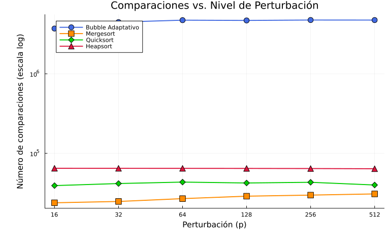

Figura 1: Número de comparaciones en función del nivel de perturbación p (escala logarítmica).

```julia
colores = [:royalblue, :darkorange, :green3, :crimson]
marcas  = [:circle, :square, :diamond, :utriangle]

# Etiquetas de cadena para evitar que p=16 y p=32 se solapen en el eje X
p_labels = string.(p_values)

fig_comps = plot(
    title    = "Comparaciones vs. Nivel de Perturbación",
    xlabel   = "Perturbación (p)",
    ylabel   = "Número de comparaciones (escala log)",
    legend   = :topleft,
    xticks   = (1:length(p_values), p_labels),
    yaxis    = :log10,
    ytickfontsize = 8,
    grid     = true,
    size     = (800, 500),
    left_margin  = 10Plots.mm,
    bottom_margin = 8Plots.mm,
)

for (j, nombre) in enumerate(nombres_alg)
    plot!(fig_comps, 1:length(p_values), mat_comps[:, j],
          label  = nombre,
          color  = colores[j],
          marker = marcas[j],
          lw = 2, ms = 6)
end
fig_comps
```

#### Tiempo de ejecución por nivel de perturbación

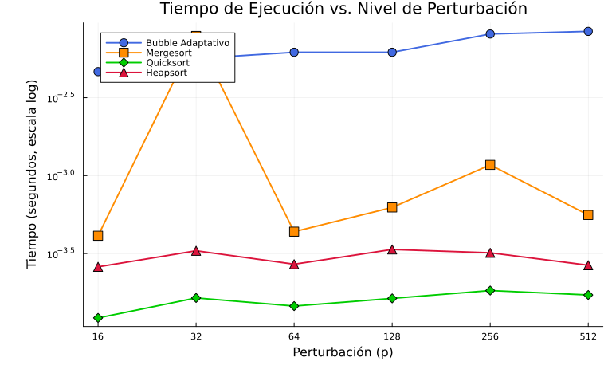

Figura 2: Tiempo promedio de ejecución (5 repeticiones) en función de p (escala logarítmica).

```julia
fig_time = plot(
    title    = "Tiempo de Ejecución vs. Nivel de Perturbación",
    xlabel   = "Perturbación (p)",
    ylabel   = "Tiempo (segundos, escala log)",
    legend   = :topleft,
    xticks   = (1:length(p_values), p_labels),
    yaxis    = :log10,
    ytickfontsize = 8,
    grid     = true,
    size     = (800, 500),
    left_margin  = 10Plots.mm,
    bottom_margin = 8Plots.mm,
)

for (j, nombre) in enumerate(nombres_alg)
    plot!(fig_time, 1:length(p_values), mat_tiempo[:, j],
          label  = nombre,
          color  = colores[j],
          marker = marcas[j],
          lw = 2, ms = 6)
end
fig_time
```

#### Razón de comparaciones (normalizada)

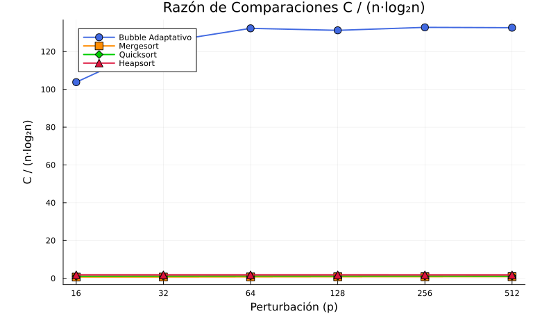

Figura 3: Razón C/(n·log₂n) por algoritmo. Valores estables indican comportamiento O(n log n); valores crecientes revelan comportamiento supralineal.

```julia
mat_razon = mat_comps ./ nlogn

fig_razon = plot(
    title    = "Razón de Comparaciones C / (n·log₂n)",
    xlabel   = "Perturbación (p)",
    ylabel   = "C / (n·log₂n)",
    legend   = :topleft,
    xticks   = (1:length(p_values), p_labels),
    grid     = true,
    size     = (800, 500),
    left_margin  = 10Plots.mm,
    bottom_margin = 8Plots.mm,
)

for (j, nombre) in enumerate(nombres_alg)
    plot!(fig_razon, 1:length(p_values), mat_razon[:, j],
          label  = nombre,
          color  = colores[j],
          marker = marcas[j],
          lw = 2, ms = 6)
end
fig_razon
```